# Informe Técnico sobre Suicidio

Valeska Alves

## Introducción

Este informe presenta un resumen de las principales conclusiones del análisis de datos del proyecto Gapminder sobre las tasas de suicidio en diferentes países, incluyendo Canadá, España, Estados Unidos, Francia, Japón y Reino Unido, durante el período de 1955 a 2015. Los resultados se presentan en forma de tablas y gráficos, y se explican en relación con los objetivos marcados.

## Objetivos

```
1.  Identificar las tendencias temporales de las tasas de suicidio en diferentes países.
2.  Analizar la variación de las tasas de suicidio entre diferentes grupos de edad y género.
3.  Detectar picos y caídas en las tasas de suicidio y su correlación con eventos específicos.
4.  Explorar las correlaciones significativas entre las tasas de suicidio de diferentes grupos de edad y género.
5.  Identificar valores atípicos en las tasas de suicidio y los países y años asociados.
```

## Tabla Resumen de Indicadores

```r
# Leer y procesar los datos
df <- read.csv("filtered_df.csv")


# Filtrar los datos para incluir solo los años de 1955 a 2015
df <- df %>% filter(time >= 1955 & time <= 2015)

# Dividir los años en hasta 5 períodos
df <- df %>%
  mutate(year_category = case_when(
    time >= 1955 & time <= 1969 ~ "1955 a 1969",
    time >= 1970 & time <= 1984 ~ "1970 a 1984",
    time >= 1985 & time <= 1999 ~ "1985 a 1999",
    time >= 2000 & time <= 2015 ~ "2000 a 2015",
  ))

# Calcular indicadores resumen
summary_table <- df %>%
  group_by(year_category) %>%
  summarise(
    Total_Suicides = sum(suicide_total, na.rm = TRUE),
    Average_Suicides = mean(suicide_total, na.rm = TRUE),
    Median_Suicides = median(suicide_total, na.rm = TRUE)
  )

# Mostrar la tabla en formato bonito
kable(summary_table, caption = "Tabla Resumen de Indicadores por Categoría de Año") %>%
  kable_styling(bootstrap_options = c("striped", "hover", "condensed"))
```

Tabla Resumen de Indicadores por Categoría de Año

| year_category | Total_Suicides | Average_Suicides | Median_Suicides |
| --- | --- | --- | --- |
| 1955 a 1969 | 1022.1854 | 11.35762 | 10.10235 |
| 1970 a 1984 | 1031.7187 | 11.59234 | 12.47370 |
| 1985 a 1999 | 1035.4818 | 11.50535 | 11.55060 |
| 2000 a 2015 | 814.8086 | 10.72117 | 10.06205 |

La tabla resumen de indicadores por categoría de año muestra las tasas de suicidio desde 1955 hasta 2015, divididas en intervalos de 15 años. Se observa una disminución tanto en el número total de suicidios como en los promedios y medianas en el período de 2000 a 2015, lo que sugiere mejoras en las políticas de prevención del suicidio y el apoyo psicológico durante este tiempo. Las intervenciones en salud pública parecen haber tenido un impacto positivo en la reducción de las tasas de suicidio.

## Gráfico de Resultados Principales

A continuación, se presenta un gráfico que muestra la tendencia de las tasas de suicidio a lo largo del tiempo para los principales países.

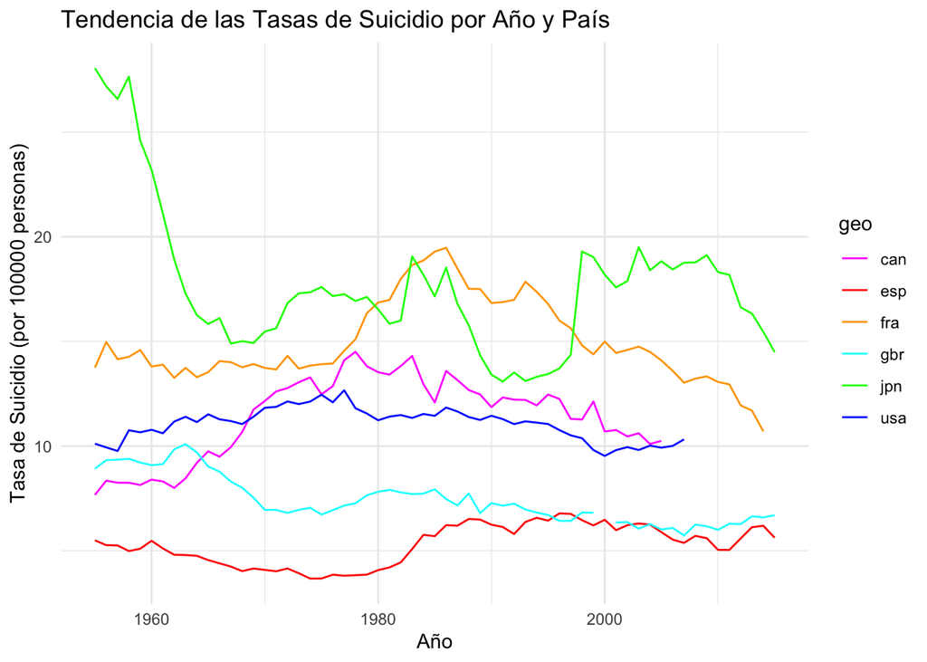

```r
# Filtrar y preparar los datos para el gráfico
top_countries <- c("usa", "gbr", "jpn", "fra", "can", "esp")
filtered_df <- df %>% filter(geo %in% top_countries)

custom_colors <- c(
  "usa" = "blue",
  "gbr" = "cyan",
  "jpn" = "green",
  "fra" = "orange",
  "can" = "magenta",
  "esp" = "red"
)

# Generar el gráfico
ggplot(filtered_df, aes(x = time, y = suicide_total, color = geo)) +
  geom_line() +
  scale_color_manual(values = custom_colors) +
  labs(title = "Tendencia de las Tasas de Suicidio por Año y País", x = "Año", y = "Tasa de Suicidio (por 100000 personas)") +
  theme_minimal()
```

Este es el gráfico principal del dashboard y muestra la tendencia de las tasas de suicidio por 100.000 personas a lo largo de los años en seis países. Se evidencian variaciones significativas en las tendencias de las tasas de suicidio entre los países analizados.

España mantiene las tasas más bajas y estables entre los países analizados.

## Correlación de Tasa de Suicidio y Países

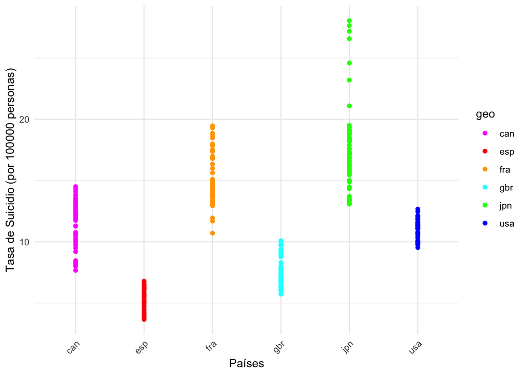

```r
filtered_data <- df

# Filtrar e preparar os dados para o gráfico
ggplot(filtered_data, aes(x = geo, y = suicide_total)) +
  geom_point(aes(color = geo)) +
  geom_smooth(method = "lm", se = FALSE) +
  scale_color_manual(values = custom_colors) +
  labs(x = "Países", y = "Tasa de Suicidio (por 100000 personas)") +
  theme_minimal() +
  theme(axis.text.x = element_text(angle = 45, hjust = 1))
```

La diferencia en las tasas de suicidio entre los países puede estar influenciada por diversos factores, incluyendo políticas de salud mental, factores socioeconómicos y culturales.

- Japón destaca como el país con mayores desafíos en términos de tasas de suicidio, lo que podría indicar la necesidad de políticas más agresivas y efectivas para la prevención del suicidio.
- España, con las tasas más bajas, podría servir como un caso de estudio para entender qué políticas y factores contribuyen a mantener bajas las tasas de suicidio.

Este análisis subraya la importancia de un enfoque personalizado y específico para cada país en la implementación de políticas de prevención del suicidio y apoyo psicológico.

## Correlación de Tasa de Suicidio y Edad

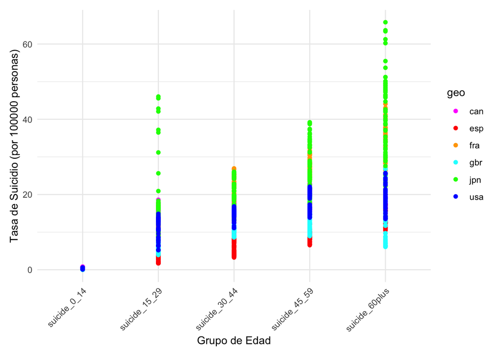

```r
filtered_data <- df

# Filtrar e preparar os dados para o gráfico
ggplot(filtered_data %>%
         gather(key = "age_group", value = "suicides", suicide_0_14:suicide_60plus) %>%
         filter(!is.na(suicides)),
       aes(x = age_group, y = suicides)) +
  geom_point(aes(color = geo)) +
  geom_smooth(method = "lm", se = FALSE) +
  scale_color_manual(values = custom_colors) +
  labs(x = "Grupo de Edad", y = "Tasa de Suicidio (por 100000 personas)") +
  theme_minimal() +
  theme(axis.text.x = element_text(angle = 45, hjust = 1),
        plot.margin = margin(10, 10, 10, 10)) # Ajusta as margens do gráfico
```

Los grupos de edad de 30 a 44 años y de 45 a 59 años presentan una cantidad moderada de suicidios, indicando que los adultos de mediana edad también son un grupo vulnerable.

El grupo de edad de 0 a 14 años presenta el menor número de suicidios, lo que puede indicar que los niños y adolescentes son menos propensos a cometer suicidio, aunque aún existen casos preocupantes.

En resumen, el gráfico destaca la importancia de intervenciones dirigidas a diferentes grupos de edad, especialmente a la población mayor, que muestra un número significativamente mayor de suicidios. Además, las políticas de prevención del suicidio deben considerar las variaciones específicas de cada país para ser efectivas.

## Correlación de Tasa de Suicidio y Genero

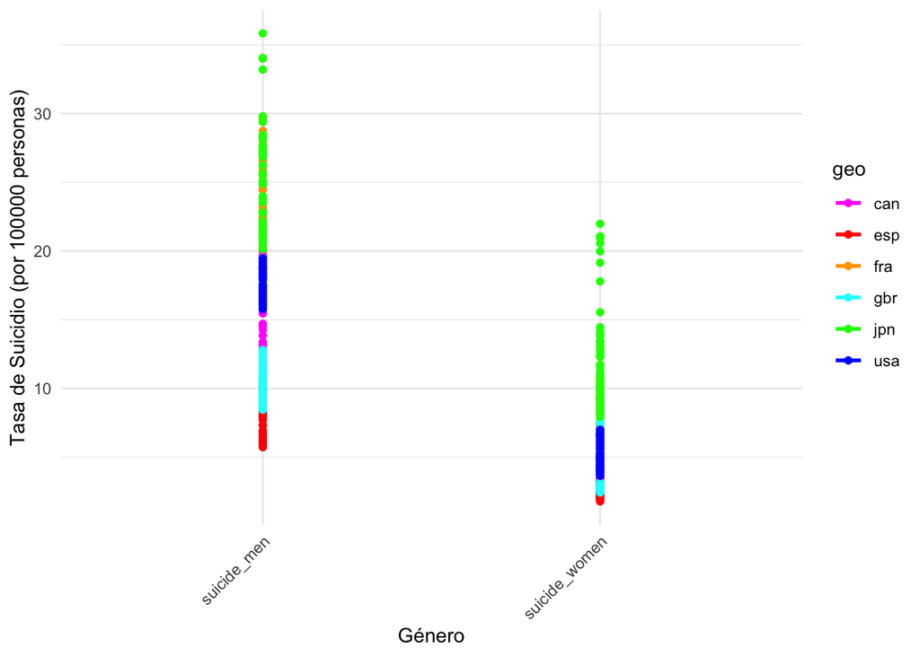

```r
filtered_data <- df

# Filtrar e preparar os dados para o gráfico
ggplot(filtered_data %>%
         gather(key = "gender", value = "suicides", suicide_men, suicide_women) %>%
         filter(!is.na(suicides)),
       aes(x = gender, y = suicides, color = geo)) +
  geom_point(aes(color = geo)) +
  geom_smooth(method = "lm", se = FALSE) +
  scale_color_manual(values = custom_colors) +
  labs(x = "Género", y = "Tasa de Suicidio (por 100000 personas)") +
  theme_minimal() +
  theme(axis.text.x = element_text(angle = 45, hjust = 1))
```

El gráfico destaca una diferencia significativa en las tasas de suicidio entre géneros, con los hombres siendo considerablemente más afectados que las mujeres en los seis países analizados. Este hallazgo subraya la necesidad de enfoques específicos por género en las políticas de prevención del suicidio, así como un análisis más profundo de los factores que contribuyen a esta disparidad entre hombres y mujeres.

## Conclusión

En resumen, los patrones observados subrayan la importancia de políticas nacionales y contextos culturales en la comprensión y mitigación de las tasas de suicidio. Un enfoque personalizado y específico para cada país, así como para diferentes grupos de edad y género, es esencial para la implementación efectiva de políticas de prevención del suicidio y apoyo psicológico. Las intervenciones en salud pública han demostrado tener un impacto positivo, y la continua mejora y adaptación de estas políticas son fundamentales para reducir las tasas de suicidio a nivel global.